# Chapter 5: Distinctive Language in the 1833 Debates About the Abolition of Slavery and 1832 Reform Bill

One of the most important tasks in history is the study of “events”—which we think of as moments when something changed. Historians ask not only what happened, but why those moments mattered and how people understood change as it unfolded. In this and future chapters, we will ask what makes certain moments historically significant and how different evidence might support our interpretation.

## Jo: Don’t other chapters contribute to a research strategy? This sounds like our first time we are teaching research. I think the prior chapters are just more basic, but not code in a vacuum.

This chapter introduces a research strategy. Up to this point, each analytical technique has been practiced separately: counting words, identifying prolific speakers, examining preferred vocabulary, and analyzing collocates to understand how meaning forms around key terms. Now, these skills come together into a single coherent research task centered on understanding a historical event. Events punctuate time, marking moments when attention intensifies and language shifts in response to political or social change. Rather than studying discourse in isolation, the goal is to identify an event, find the speakers most active around it, examine the themes and collocates they used, compare how different individuals framed the moment, and interpret what changed and why it mattered. In earlier exercises, speakers, word use, and collocates were analyzed independently; here, those same methods are combined into a unified workflow that moves from computational analysis toward historical interpretation.

That strategy is not just about measuring words or applying computational tools; it involves deciding which words are worth following and allowing time for curiosity about what interpretation makes possible. Learning to text mine is not entirely about code—it is about judgment. How do we decide which words are interesting? How do we recognize when a pattern is meaningful? How do we move from raw counts to historical argument?

To see how these questions emerge in practice, we turn to a historical example whose meaning has shifted dramatically over time. The British Abolition of Slavery in 1833, alongside the abolition of the slave trade by British naval vessels in 1806, were once celebrated as the sign that Britain was a nation committed to moral progress around the world. That claim has been significantly modified by historical research in recent years, as researchers have underscored that the abolition of slavery failed to end many forms of slavery; it wooed slave owners through instituting a prolonged form of slavery called “apprenticeships.” In India and the rest of Asia, slavery meanwhile persisted unreformed.

Studying the interplay between white male politicians as they debated the fate of millions of enslaved persons from the West Indies to South Africa is in many ways an out-of-date exercise. Today, we recognize the degree to which enslaved people across British empire struggled to liberate themselves. A persistent tradition of uprisings and riots marked their ongoing resistance. The life of ideas and leaders — even women leaders like Queen Nannie — are important to understanding the British Empire.

We will find only an indirect trace of how the freedom struggles of the Caribbean changed laws and ideas in Britain. The personages and uprisings that rocked the West Indies were rarely named in Westminster. The direct records of those events are held in pamphlets and documents in the Caribbean itself, slowly being digitalized through other means.

And yet, those freedom struggles half a world a way did matter in many respects to British life. They circulated among evangelical readers; they forced philosophers of capitalism to reckon with the way that capitalism had been instantiated as misery in many places where it was enacted. British debates about slavery came to a head in the halls of parliament after 1832, when an evangelical middle class got the vote after decades of political struggles of their own. In 1833, the elected representatives of the evangelical middle class committed themselves to talking about slavery as a moral ill and bringing it to an end across empire.

One question that might allow us to unpack the impact of abolition is how British understandings of empire and capitalism were changed in the course of those debates — in a year when both parliament and the newspapers were filled with a detailed discussion of the suffering caused by the slave system. One way of approaching the question of what happened in 1833 is to look for the ideas that were up for debate. Were any of the fundamental concepts of the enlightenment challenged or redefined in the course of these arguments?

# The Importance of Background Knowledge

Before we begin to think about the contribution that text mining can make to the problem, we first need to be able to summarize the understanding and debates of the historians who have studied these questions.<sup>1</sup> The paragraphs above summarize some of the different perspectives on the slavery question taken by historians from the recent and more distant past. In short, we need some background knowledge. But how does an analyst get there, if they don’t first have a series of prepared paragraphs to introduce them to a historical problem?

“Background knowledge” in a subject field refers to the kind of knowledge that one acquires by reading the major textbooks and secondary monographs from the field of History that cover the historical time period in question. Textbooks and secondary monographs provide extensive knowledge about which sources have been consulted, what scholars have debated, whether the actions of kings or parliaments or working-class people mattered at this period of time and why.

Remarks about the importance of reading background information may be experienced as off-putting by some undergraduate students of data, who want to be assured that in a course on text mining that they will acquire the tools to make wonderful discoveries. But just as students of statistics must study more than an introductory course in statistics to make a novel contribution, so too students of text mining must enroll in more than one course to do really important work. Reading a Wikipedia entry cannot substitute for the kind of background knowledge that a student would acquire in the course of taking an introductory course on the History of Victorian England. Nor can Text Mining for Historical Analysis make up for courses in the undergraduate study of History, although this book’s companion volume, The Dangerous Art of Text Mining, includes many arguments about the specific kind of knowledge of sources, obfuscations, agency, and experience that historical study makes available. Producing insight worthy of the attention of multiple fields is no simple game. It cannot be produced at the touch of a button or the application of a new algorithm to new data; it requires adjusting the algorithm, rethinking the questions, examining the data, and iterating through the work until something truly surprising has come to light.

In ‘hybrid’ work, where computer scientists and humanists work on the same team to produce new knowledge, collaborating over multiple iterations and investigations, there can be a division of labor around the research. In general, a high caliber of work can only be accomplished by teams where at least one valued member is as serious about history as they are about algorithmic study.

Not every historian needs access to every kind of background knowledge. If a course on Victorian Britain offers the ideal background for text mining the parliamentary debates, a course on American history offers a much better background to working with the Congressional Record. Scholars who have studied Latin American, African, or Asian history will necessarily have the background to work with other datasets. The point here is that understanding a time and a place represents a commitment of reading dozens of books. No single Wikipedia article or textbook will substitute for this work, and only this background work really equips an analyst to ask the questions about consensus and surprise that outfit an analyst for understanding when their data work is validating what scholars already know and when their data work has advanced to the discovery of something truly surprising.

For the purpose of our question about the abolition debatees in parliament, we recommend extra background reading in the major sources we consulted to summarize the debates above:

- David Ryden, West Indian Slavery and British Abolition, 1783-1807 (Cambridge: Cambridge University Press, 2005)
- Adam Hochschild, Bury the Chains: Prophets and Rebels in the Fight to Free an Empire (Boston: Houghton Mifflen, 2006).
- Christopher Leslie Brown, Moral Capital: Foundations of British Abolitionism (Chapel Hill: University of North Carolina Press, 2006)
- Richard Huzzey, Freedom Burning: Salvery and Empire in Victorian Britain (Ithaca: Cornell University Press, 2012).
- Claudius K. Fergus, Revolutionary Emancipation, Slavery and Abolitionism in the British West Indies (Baton Rouge, Louisiana State University Press, 2013).
- Robert Burroughs and Richard Huzzey, eds., The Suppression of the Atlantic Slave Trade (Manchester: Manchester University Press, 2015)
- Paula Dumas, Proslavery Britain: Fighting for Slavery in an Era of Abolition (New York: Palgrave Macmillan, 2016).
- Padraic X. Scanlan, Slave Empire: How Slavery Built Modern Britain (Boston: Little, Brown, 2020).
- Tom Zoellner, Island on Fire: The Revolt that Ended Slavery in the British Empire (Cambridge: Harvard University Press, 2022).

Note that we have attempted to gather titles from the past two decades, with perspectives ranging from an overview of the abolition movement to the biography of the abolitionists, to the pro-slavery lobby that argued against abolition and for apprenticeships, to the larger question of how imbricated slavery was within the British economy, to the Jamaican revolt of 1831 that forced Britain to end slavery.

Engagement with historical secondary sources is one of the markers of serious Digital History work which is frequently absent in publications from Computer Science or Data Science, with the result that it is sometimes unclear what the original contribution of a given article is to the historical literature. We believe that setting a higher standard of innovation in scholarship –- by demanding findings that are literally surprising to the field – is a healthy practice, raising the bar for computational investigations of the human past.

The analyst beginning research on a problem of this kind does not necessarily have to read all of these books with equal attentiveness. But it is useful to spend a few hours reading at least the introductions to these books (or more recent contributions to the debate) to see what the authors agree and disagree about, which themes or ideas they find most interesting.

In the sections of text that follow, as we pursue the question more deeply, we will return to secondary sources, seeking out more specialized texts, for instance biographies of the individuals whose words we count. Pay attention to the footnotes and the texts that we cite to understand how the need for background knowledge evolves with research.

# Finding the Research Question that the Tools of Text Mining Can Address

First, we need to think about the fit between the tools of text mining and the issue of the abolition of slavery. As explained above, we don’t have the source base in Hansard to contribute to burning questions about the role of enslaved persons in pursuing their own freedom. If all we have is Hansard, we need to retailor our question to the dataset we have. With Hansard, we can count mentions of slavery and the way that slavery is addressed by the spakers who were in power at the time when slavery was nominally abolished throughout British empire. Can we write a research question that might light to insights on the basis of word count?

One place to start is with the speakers in parliament who contributed the most to the 1833 debates about slavery. As we saw in a previous chapter, one place where text mining excels is simply counting the number of words contributed to a given issue by individual speakers. Based on word counts, we can expect to accurately identify the speakers in parliament who contributed the most to the slavery question.

We can then move to asking about the language they shared to the language that makes each of their contributions unique. Another place where text mining excels is counting the words from each individual speaker, finding the words they shared and the words that were most distinctive of each speaker.

Why would we want to understand the words that made the principal speakers different? Because it may tell us something important about what they disagreed about. An understanding of the poles of debate can lead us to a detailed case about the tensions that emerged in parliament around abolition.

From this question we may be able to navigate to an original contribution about the role of arguments in parliament, perhaps contributing information that other historians have not been able to pull from their research.

## Top Speakers in the Debates About Slavery

In a previous chapter, we looked into the top speakers in parliament in a given year. In this exercise, we want to begin by finding just those speakers who spoke the most in debates about slavery. We can use `str_detect()` to look for the word “slavery” in the titles of debate. Then we could the top speakers.

If you are new to code, take a moment to notice how changing only one line in the code below produces a different angle of analysis. The code below is otherwise very similar to the code in the previous chapters. One of the great pleasures of coding is the facility with which a few skills can quickly become powerful in the hands of an analyst who has many questions.

```r
# For accessing Hansard
library(hansardr)

# For data processing and text analysis
library(tidyverse)
library(tidytext)
library(textstem)

# For working with dates and times
library(lubridate)

# For creating and formatting visualizations
library(ggrepel)
library(scales)

# For formatting tables
library(knitr)

# load data
data("hansard_1830")
data("debate_metadata_1830")

# Find debates about slavery in the 1830 Hansard data
# - left_join() adds debate titles and speech dates
# - filter() keeps only debates with "slavery" in the title
# - mutate() extracts the year from the speech date
slavery_1830 <- hansard_1830 %>%
  left_join(debate_metadata_1830, by = "sentence_id") %>% # Add debate metadata
  filter(str_detect(tolower(debate), "slavery")) %>% # Keep slavery debates
  mutate(year = year(speechdate)) # Extract the year

# Add speaker information to the slavery debates
# - left_join() adds speaker metadata
# - select() keeps only the variables needed for analysis
# - filter() removes rows without a speaker name
slavery_debates_1830 <- slavery_1830 %>%
  left_join(speaker_metadata_1830, by = "sentence_id") %>% # Add speaker metadata
  select(sentence_id, speaker, suggested_speaker, text, year) %>% # Keep relevant columns
  filter(suggested_speaker != "") # Remove missing speaker names

# Break the speeches into individual words
# - unnest_tokens() tokenizes the text into one word per row
slavery_words_1830 <- slavery_debates_1830 %>%
  unnest_tokens(word, text)

# Count how many words each speaker contributed
# - group_by() groups the data by speaker
# - summarize() counts the total words spoken by each speaker
# - arrange() sorts speakers from most to fewest words
words_per_speaker_slavery_1830 <- slavery_words_1830 %>%
  group_by(speaker) %>% # Group by speaker
  summarize(words_per_speaker = n()) %>% # Count words per speaker
  arrange(desc(words_per_speaker)) # Sort from most to fewest words

# Keep the speakers who contributed the most words
# - ungroup() removes the previous grouping
# - arrange() sorts speakers from most to fewest words
# - slice() keeps the top 20 rows
top_slavery_speakers <- words_per_speaker_slavery_1830 %>%
  ungroup() %>% # Remove the grouping
  arrange(desc(words_per_speaker)) %>% # Sort from most to fewest words
  slice(1:20) # Keep the top 20 rows

# Count the number of words spoken by each speaker in each year
# - group_by() groups the data by speaker and year
# - summarize() counts the words in each speaker-year combination
# - arrange() sorts the results from most to fewest words
words_per_speaker_per_year_slavery_1830 <- slavery_words_1830 %>%
  group_by(speaker, year) %>% # Group by speaker and year
  summarize(words_pspy = n()) %>% # Count words per speaker per year
  arrange(desc(words_pspy)) # Sort from most to fewest words

# Count the number of words spoken by each speaker in each year
# - group_by() groups the data by speaker and year
# - summarize() counts the words in each speaker-year combination
# - arrange() sorts the results from most to fewest words
words_per_speaker_per_year_slavery_1830 <- slavery_words_1830 %>%
  group_by(speaker, year) %>% # Group by speaker and year
  summarize(words_pspy = n()) %>% # Count words per speaker per year
  arrange(desc(words_pspy)) # Sort from most to fewest words

# Keep yearly word counts for only the top speakers
# - filter() keeps only speakers in the top speaker list
# - %in% checks whether each speaker appears in that list
top_words_pspy_slavery_1830 <- words_per_speaker_per_year_slavery_1830 %>%
  filter(speaker %in% unique(top_slavery_speakers$speaker)) # Keep only the top speakers
```

Now we can visualize who spoke about slavery in 1830, how much they said, and when they spoke. Each point represents a speaker’s total words for a given year. The x-axis shows years (rounded to whole numbers), and the y-axis shows word counts.

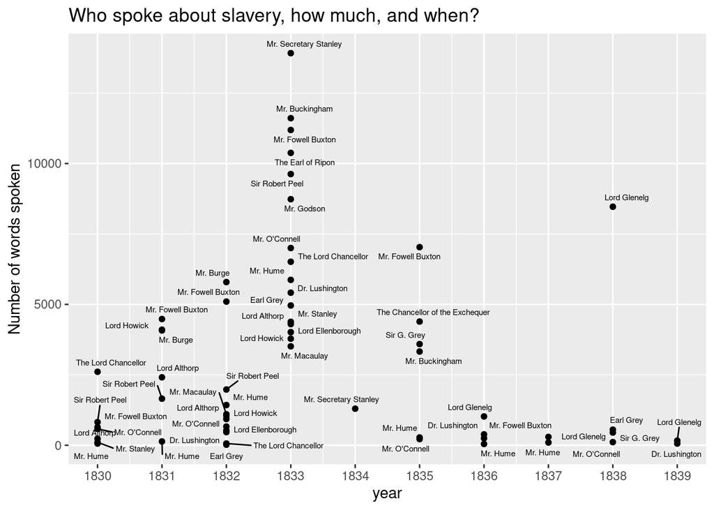

```r
# Visualize when the top speakers discussed slavery
# - ggplot() creates a scatterplot of yearly word counts
# - geom_point() plots one point for each speaker-year combination
# - geom_text_repel() labels speakers while reducing overlapping text
ggplot(top_words_pspy_slavery_1830,
       aes(x = year, # Map year to the x-axis
           y = words_pspy, # Map word count to the y-axis
           label = speaker)) + # Label points with speaker names
  geom_text_repel(size = 2) + # Add non-overlapping labels
  geom_point() + # Plot each speaker-year point
  ggtitle("Who spoke about slavery, how much, and when?") + # Add a title
  ylab("Number of words spoken") + # Label the y-axis
  scale_x_continuous(breaks = unique(top_words_pspy_slavery_1830$year)) # Show whole numbers for years
```

You may notice that we have produced a different sort of visualization than the bar charts of the previous chapter. The ggplot library of graphics is a highly flexible language for producing many visualizations from the same data. Rather than the command for a bar chart – `geom_col()` – we have used a command for a dot plot – `geom_point()`. With this plot we also introduce another library, `ggrepel`, which gives us tools for enhancing the readability of our plot by making sure that labels do not overlap.

Exploring the contributions of the top speakers and the tensions between them is one area in which the tools of text mining excel.

## Using Our Skills to Explore the Historical Debates About the Abolition of Slavery

Understanding how to group data by speaker and year gives us the possibility of closely studying the contribution of different speakers. For instance, suppose that we wanted to read all of the debates relating to Slavery Abolition Act of 1833, which went into effect in 1834 and outlawed slavery in many British colonies, including the Caribbean and South Africa, although not across much of India, where debt slavery would persist for decades, and where the caste system would exclude many people from participation in the economy through the twenty-first century.

There are some new commands below that are used for demonstration purposes to show how one might navigate our newly joined dataset. Don’t feel worried if you can’t read every line. You will be learning how to aggregate data by speaker very soon.

[output not shown]

Counting how many words were spoken in the 6,000 some sentences about the abolition of British slavery is our first reminder of the bias of this data set: the speakers are white men, many of them of a class invested in slavery. This collection of words is not suitable for investigating narratives that depict lived experiences of dehumanization, recorded from the words of enslaved people.

In the following code, we provide a list of speakers and use the `%in%` operator to filter for any of these speakers.

```r
# Create a list of the top speakers to analyze
top_speaker_names <- c("Mr. Fowell Buxton", "Mr. Buckingham", "Mr. Stanley",
                       "The Duke of Wellington", "Sir Robert Peel")

# Keep speeches by only the selected speakers
# - filter() keeps rows where the speaker is in top_speaker_names
top_slavery_speakers_1833 <- slavery_debates_1833 %>%
  filter(speaker %in% top_speaker_names) # Keep the selected speakers

# Preview the first few speeches
# - head() shows the first few rows
# - mutate() shortens the speech text for display
# - kable() formats the output as a table
top_slavery_speakers_1833 %>%
  head() %>% # Show the first rows
  mutate(text = str_trunc(text, 120)) %>% # Shorten the speech text
  kable() # Display the results as a table
```

| sentence_id | speaker | suggested_speaker | text | year |
| --- | --- | --- | --- | --- |
| S3V0016P0_13594 | Mr. Fowell Buxton | thomas_buxton_2122 | replied, that no man was more conscious than he was how much better it would be for the subject to be introduced by G… | 1833 |
| S3V0016P0_13595 | Mr. Fowell Buxton | thomas_buxton_2122 | First, if Ministers were prepared with a plan for the entire and immediate extinction of slavery; second, if they wou… | 1833 |
| S3V0016P0_13596 | Mr. Fowell Buxton | thomas_buxton_2122 | He might be thought very obstinate, and he was far from wishing to impede the measures of Government, but he well kne… | 1833 |
| S3V0016P0_13597 | Mr. Fowell Buxton | thomas_buxton_2122 | Until June next there was not a vacant day in the Order-book, and, after Easter, the great questions of the Bank of E… | 1833 |
| S3V0016P0_13598 | Mr. Fowell Buxton | thomas_buxton_2122 | To postpone his Motion, therefore, would in effect be to abandon it. | 1833 |
| S3V0016P0_13599 | Mr. Fowell Buxton | thomas_buxton_2122 | Now, he was convinced, that it was absolutely indispensable that this question should be settled; and further, that i… | 1833 |

Next, let’s break the text into words and clean it up, removing numbers and stop words. We’re lemmatizing each word into its word stem so that we can count singular and plural of the same word as one.

```r
# Clean and tokenize the speeches
# - unnest_tokens() tokenizes the text into one word per row
# - filter() removes tokens that contain only numbers
# - anti_join() removes common stop words
# - mutate() lemmatizes each word
filtered_words_per_top_slavery_speaker_1833 <- top_slavery_speakers_1833 %>% # Start with the selected speakers
  unnest_tokens(word, text) %>% # Break the text into words
  filter(!str_detect(word, "^\\d+$")) %>% # Remove numbers
  anti_join(stop_words, by = "word") %>% # Remove stop words
  mutate(word = lemmatize_words(word)) # Lemmatize the words

# Inspect the cleaned data
head(filtered_words_per_top_slavery_speaker_1833)
```

```
## # A tibble: 6 × 5
##   sentence_id     speaker           suggested_speaker   year word
##   <chr>           <chr>             <chr>              <dbl> <chr>
## 1 S3V0016P0_13594 Mr. Fowell Buxton thomas_buxton_2122  1833 reply
## 2 S3V0016P0_13594 Mr. Fowell Buxton thomas_buxton_2122  1833 conscious
## 3 S3V0016P0_13594 Mr. Fowell Buxton thomas_buxton_2122  1833 subject
## 4 S3V0016P0_13594 Mr. Fowell Buxton thomas_buxton_2122  1833 introduce
## 5 S3V0016P0_13594 Mr. Fowell Buxton thomas_buxton_2122  1833 government
## 6 S3V0016P0_13594 Mr. Fowell Buxton thomas_buxton_2122  1833 relinquish
```

Next, let’s count the words by how many times each speaker says them.

For our visualization, we will look at only the words spoken most frequently.

```r
# Count how often each speaker uses each word
# - group_by() groups the data by speaker and word
# - summarize() counts how many times each word appears
# - arrange() sorts the words from most to fewest occurrences
abolition_speaker_wordcounts <- filtered_words_per_top_slavery_speaker_1833 %>%
  group_by(speaker, word) %>% # Group by speaker and word
  summarize(n = n()) %>% # Count occurrences of each word
  arrange(desc(n)) # Sort from most to fewest occurrences

# Keep the most frequently used words
# - slice() keeps the first 15 rows
top_words_per_abolition_speaker <- abolition_speaker_wordcounts %>%
  slice(1:15) # Keep the top 15 rows

kable(top_words_per_abolition_speaker)
```

| speaker | word | n |
| --- | --- | --- |
| Mr. Buckingham | slave | 75 |
| Mr. Buckingham | labour | 59 |
| Mr. Buckingham | slavery | 42 |
| Mr. Buckingham | freedom | 38 |
| Mr. Buckingham | free | 34 |
| Mr. Buckingham | west | 32 |
| Mr. Buckingham | hon | 26 |
| Mr. Buckingham | time | 26 |
| Mr. Buckingham | emancipation | 25 |
| Mr. Buckingham | sugar | 25 |
| Mr. Buckingham | house | 23 |
| Mr. Buckingham | colony | 22 |
| Mr. Buckingham | negro | 22 |
| Mr. Buckingham | country | 21 |
| Mr. Buckingham | indies | 17 |
| Mr. Fowell Buxton | negro | 80 |
| Mr. Fowell Buxton | slave | 64 |
| Mr. Fowell Buxton | hon | 52 |
| Mr. Fowell Buxton | wage | 40 |
| Mr. Fowell Buxton | house | 37 |
| Mr. Fowell Buxton | planter | 36 |
| Mr. Fowell Buxton | labour | 31 |
| Mr. Fowell Buxton | west | 30 |
| Mr. Fowell Buxton | apprenticeship | 29 |
| Mr. Fowell Buxton | gentleman | 28 |
| Mr. Fowell Buxton | day | 22 |
| Mr. Fowell Buxton | government | 21 |
| Mr. Fowell Buxton | pay | 20 |
| Mr. Fowell Buxton | slavery | 20 |
| Mr. Fowell Buxton | system | 20 |
| Mr. Stanley | hon | 52 |
| Mr. Stanley | government | 20 |
| Mr. Stanley | labour | 20 |
| Mr. Stanley | slave | 17 |
| Mr. Stanley | house | 16 |
| Mr. Stanley | free | 15 |
| Mr. Stanley | plan | 15 |
| Mr. Stanley | gentleman | 13 |
| Mr. Stanley | question | 13 |
| Mr. Stanley | slavery | 12 |
| Mr. Stanley | sugar | 12 |
| Mr. Stanley | measure | 11 |
| Mr. Stanley | period | 10 |
| Mr. Stanley | planter | 10 |
| Mr. Stanley | effect | 9 |
| Sir Robert Peel | slave | 102 |
| Sir Robert Peel | house | 47 |
| Sir Robert Peel | resolution | 44 |
| Sir Robert Peel | slavery | 43 |
| Sir Robert Peel | colony | 40 |
| Sir Robert Peel | question | 38 |
| Sir Robert Peel | hon | 37 |
| Sir Robert Peel | labour | 29 |
| Sir Robert Peel | freedom | 26 |
| Sir Robert Peel | west | 26 |
| Sir Robert Peel | emancipation | 24 |
| Sir Robert Peel | opinion | 20 |
| Sir Robert Peel | country | 19 |
| Sir Robert Peel | legislature | 19 |
| Sir Robert Peel | plan | 19 |

Now visualize:

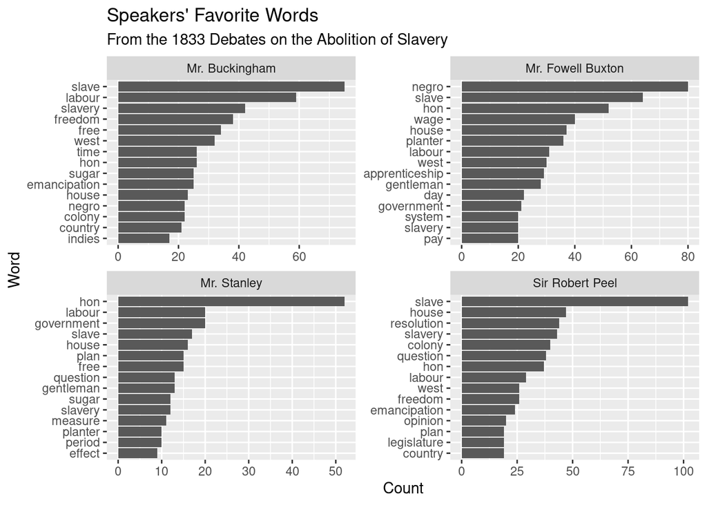

## From Concepts to ideas

What can we learn from this visualization about the history of slavery? How might we use the tools of text mining to learn something new about this important historical moment?

Historians believe that identifying the debates over these words is key to understanding the abstract forces that remade society, or the “conceptual changes” by which modern understanding was produced. Peter de Bolla and his coauthors defined concepts as “‘cultural entities’ held by many agents collectively, that is held by a ‘culture’.”<sup>2</sup> They argue that concepts allow cultures to feel their way through increasingly abstract modes of ideation, because concepts “provide the scaffolding that enables one to understand whatever is the object of attention and thought.” In the era of the debates over the abolition of slavery, the concept “freedom” was doing just such important work, allowing ordinary British people and the politicians who represented them to reckon with certain aspects of the abhorrent economic reality that made Britain so rich in the age of empire: the fact that Britain’s wealth was largely due to the plunder of wealth from foreign lands and especially the theft of time from the millions of enslaved humans who harvested sugar, tea, cotton, and the other raw materials upon which empire’s trade was based. Talking about “freedom” formed the basis for reckoning with capitalism and empire as systems, for holding them account to a higher set of principles. That work was at its infancy in the era of the British laws that outlawed the Atlantic slave trade and slavery in some parts of British empire, but the work of defining and promoting freedom continues to this day as the specific cases and principles that comprise freedom continue to be brought into consciousness through the work of social movements, politics, and ideation.

Historically speaking, as concepts arise, they tend to be contested. At the beginning, there was no single definition of “science” or “nation” to which all parties subscribed; these terms had to be debated and argued over until they became abstract ideas that could be invoked in support of other debates. Corpus linguistics gives us useful clues about how to identify potential concepts: as a rule of thumb, the words spoken about the most in any debates are those that are most contested. In the debates of 1833, we can tell that the words “slavery,” “freedom,” and “labour” may fit such a description. Often the words spoken most frequently are words whose definition is up for grabs; speakers who disagree with each other will talk at great length to assert their own definition of one of these key concepts. The two speakers who mention freedom the most in 1833 are Buckingham and Peel, and we might expect that they represent two poles of disagreement about what freedom is or should be.

One part of unpacking the life of concepts is to understand the contestation of concepts by individuals as they formulate ideas and arguments. In this usage, we follow de Bolla and his collaborators call the individual uses of concepts by writers and speakers “ideas.”<sup>3</sup>. Therefore, for the following discussion, let us use “concept” to reference that shared terminology of values, especially “freedom,” while reserving “idea” for any other terms we might use to understand how individual speakers make their cases. When people in the past argued about how to define terms like “freedom,” they used many examples. Words such as “wages,” “apprenticeship,” and “regulation” were used in the slavery debates to signal how freedom was to be achieved.

Our many parenthetical remarks in the paragraph are an important reminder that we are merely at the stage of hypothesis generation. We do not have enough material from this list of keywords to interpret the debates. We may begin to identify words and speakers for further analysis.

### The Most Distinctive Words of the Top Speakers About Slavery

What we need is a “distinctiveness measure,” a statistical tool that allows us to rank an index of how “distinctive” a word is of each speaker. Further on in this book, we will go into the technicalities of measures of distinction in greater detail, the varieties of algorithms that can be used for this purpose, and how they work. For now, it is enough to know that “distinctiveness” is a useful tool for understanding which words each speakers says more relative to the other speakers.

Distinctiveness can help us to answer the question: what were the words that Buckingham said that other speakers did not say? What were the words that Peel uttered that other speakers never used? If raw word count helps us to understand which concepts speakers may be arguing over, distinctiveness helps us to interpret which keywords those speakers used to support their argument.

Using the function `bind_tf_idf()` we can apply an index of how distinctive each word is of each speaker. The tf-idf function will create an index for each term-speaker pair – a number which, if high, tells us that the word was very distinctive of each speaker, and if low, tell us that many of the speakers used the same word.

The `bind_tf_idf()` function takes three arguments. The first two are the names of the facets of the data which are to be assessed for how distinctive they are in relationship to each other – in this case, `word` and `speaker`. The third argument, `n`, the count of words per speaker.

```r
# Calculate how distinctive each word is for each speaker
# - bind_tf_idf() calculates the tf-idf score for each word
# - arrange() sorts the words from highest to lowest tf-idf score
tfidf_per_top_slavery_speaker_1833 <- abolition_speaker_wordcounts %>%
  bind_tf_idf(word, speaker, n) %>% # Calculate tf-idf scores
  arrange(desc(tf_idf)) # Sort from highest to lowest tf-idf

tfidf_per_top_slavery_speaker_1833 %>%
  head(50) %>%
  kable()
```

| speaker | word | n | tf | idf | tf_idf |
| --- | --- | --- | --- | --- | --- |
| Mr. Stanley | rashness | 4 | 0.0029304 | 1.3862944 | 0.0040624 |
| Mr. Stanley | baronet | 7 | 0.0051282 | 0.6931472 | 0.0035546 |
| Sir Robert Peel | involve | 8 | 0.0025592 | 1.3862944 | 0.0035478 |
| Sir Robert Peel | ultimate | 8 | 0.0025592 | 1.3862944 | 0.0035478 |
| Mr. Fowell Buxton | wage | 40 | 0.0116313 | 0.2876821 | 0.0033461 |
| Sir Robert Peel | imperial | 7 | 0.0022393 | 1.3862944 | 0.0031043 |
| Mr. Stanley | essex | 6 | 0.0043956 | 0.6931472 | 0.0030468 |
| Mr. Stanley | export | 3 | 0.0021978 | 1.3862944 | 0.0030468 |
| Mr. Stanley | importation | 3 | 0.0021978 | 1.3862944 | 0.0030468 |
| Mr. Stanley | scramble | 3 | 0.0021978 | 1.3862944 | 0.0030468 |
| Mr. Fowell Buxton | rear | 7 | 0.0020355 | 1.3862944 | 0.0028218 |
| Sir Robert Peel | majority | 6 | 0.0019194 | 1.3862944 | 0.0026608 |
| Mr. Buckingham | enjoyment | 14 | 0.0036101 | 0.6931472 | 0.0025023 |
| Mr. Buckingham | political | 7 | 0.0018051 | 1.3862944 | 0.0025023 |
| Mr. Fowell Buxton | hottentots | 6 | 0.0017447 | 1.3862944 | 0.0024187 |
| Mr. Buckingham | person | 13 | 0.0033522 | 0.6931472 | 0.0023236 |
| Sir Robert Peel | can | 5 | 0.0015995 | 1.3862944 | 0.0022174 |
| Sir Robert Peel | king’s | 5 | 0.0015995 | 1.3862944 | 0.0022174 |
| Mr. Fowell Buxton | council | 11 | 0.0031986 | 0.6931472 | 0.0022171 |
| Mr. Buckingham | thirdly | 6 | 0.0015472 | 1.3862944 | 0.0021449 |
| Mr. Stanley | growth | 4 | 0.0029304 | 0.6931472 | 0.0020312 |
| Mr. Stanley | practicability | 4 | 0.0029304 | 0.6931472 | 0.0020312 |
| Mr. Stanley | venezuela | 4 | 0.0029304 | 0.6931472 | 0.0020312 |
| Mr. Stanley | accuse | 2 | 0.0014652 | 1.3862944 | 0.0020312 |
| Mr. Stanley | barrel | 2 | 0.0014652 | 1.3862944 | 0.0020312 |
| Mr. Stanley | bite | 2 | 0.0014652 | 1.3862944 | 0.0020312 |
| Mr. Stanley | burnley | 2 | 0.0014652 | 1.3862944 | 0.0020312 |
| Mr. Stanley | exportation | 2 | 0.0014652 | 1.3862944 | 0.0020312 |
| Mr. Stanley | mine | 2 | 0.0014652 | 1.3862944 | 0.0020312 |
| Mr. Stanley | plunge | 2 | 0.0014652 | 1.3862944 | 0.0020312 |
| Mr. Stanley | precipitation | 2 | 0.0014652 | 1.3862944 | 0.0020312 |
| Mr. Stanley | reduction | 2 | 0.0014652 | 1.3862944 | 0.0020312 |
| Mr. Stanley | rum | 2 | 0.0014652 | 1.3862944 | 0.0020312 |
| Mr. Stanley | solve | 2 | 0.0014652 | 1.3862944 | 0.0020312 |
| Mr. Stanley | unrestricted | 2 | 0.0014652 | 1.3862944 | 0.0020312 |
| Mr. Fowell Buxton | flog | 5 | 0.0014539 | 1.3862944 | 0.0020155 |
| Mr. Buckingham | buckingham | 5 | 0.0012893 | 1.3862944 | 0.0017874 |
| Mr. Buckingham | love | 5 | 0.0012893 | 1.3862944 | 0.0017874 |
| Mr. Buckingham | perfectly | 5 | 0.0012893 | 1.3862944 | 0.0017874 |
| Mr. Buckingham | week | 5 | 0.0012893 | 1.3862944 | 0.0017874 |
| Sir Robert Peel | affect | 8 | 0.0025592 | 0.6931472 | 0.0017739 |
| Sir Robert Peel | qualify | 8 | 0.0025592 | 0.6931472 | 0.0017739 |
| Sir Robert Peel | hazard | 4 | 0.0012796 | 1.3862944 | 0.0017739 |
| Sir Robert Peel | precaution | 4 | 0.0012796 | 1.3862944 | 0.0017739 |
| Sir Robert Peel | legislature | 19 | 0.0060781 | 0.2876821 | 0.0017485 |
| Mr. Stanley | average | 8 | 0.0058608 | 0.2876821 | 0.0016860 |
| Mr. Stanley | state | 8 | 0.0058608 | 0.2876821 | 0.0016860 |
| Mr. Fowell Buxton | accomplish | 8 | 0.0023263 | 0.6931472 | 0.0016124 |
| Mr. Fowell Buxton | cost | 8 | 0.0023263 | 0.6931472 | 0.0016124 |
| Mr. Fowell Buxton | motion | 8 | 0.0023263 | 0.6931472 | 0.0016124 |

Note that the `bind_tf_idf()` function creates three new columns – `tf`, `idf`, and `tf_idf`. The one we really care about is the last, `tf_idf`, an index of how distinctive each word is of each speaker. A very high `tf_idf` marks words that are said very frequently by one speaker and never by any other speakers. A very low tf_idf marks words that are rarely said by anyone or said by everyone with nearly the same frequency. Looking for the high `tf_idf` words for each speaker will tell us which words are most unique to them – a useful clue to the distinctive arguments, ideas, and referents that each speaker contributed to the debate.

Now that we have an index of how distinctive each word is per speaker, we can use this distinctiveness tool to find which words are most distinctive of each speaker.

```r
# Find the most distinctive words for each speaker
# - group_by() groups the data by speaker
# - arrange() sorts words from highest to lowest tf-idf score
# - slice() keeps the top 15 words for each speaker
# - mutate() adds a ranking column and rounds the tf-idf scores
# - select() keeps only the columns needed for display
most_distinctive_words_per_abolition_speaker <- tfidf_per_top_slavery_speaker_1833 %>%
  group_by(speaker) %>% # Group by speaker
  arrange(desc(tf_idf)) %>% # Sort by tf-idf score
  slice(1:15) %>% # Keep the top 15 words
  ungroup() %>% # Remove the grouping
  mutate(index = row_number(), # Add a ranking column
         tf_idf = round(tf_idf, 4)) %>% # Round the tf-idf scores
  select(index, word, tf_idf, n, speaker) # Keep the relevant columns
```

To select each speaker, we will index the corresponding name in `top_speaker_names` using square brackets (`[]`). To see which speaker corresponds to each index, inspect `top_speaker_names`.

```r
top_speaker_names
```

```
## [1] "Mr. Fowell Buxton"      "Mr. Buckingham"         "Mr. Stanley"
## [4] "The Duke of Wellington" "Sir Robert Peel"
```

```r
# Create a dataset for the first speaker, Mr. Fowell Buxton
# - filter() keeps only speeches by the first speaker in top_speaker_names
# - select() keeps only the word and tf-idf columns
speaker1 <- most_distinctive_words_per_abolition_speaker %>%
  filter(speaker == top_speaker_names[1]) %>% # Keep the first speaker
  select(word, tf_idf) # Keep the relevant columns

# Do the same for speeches by the second speaker, Mr. Buckingham
speaker2 <- most_distinctive_words_per_abolition_speaker %>%
  filter(speaker == top_speaker_names[2]) %>%
  select(word, tf_idf)

# Do the same for speeches by the third speaker, Mr. Stanley
speaker3 <- most_distinctive_words_per_abolition_speaker %>%
  filter(speaker == top_speaker_names[3])%>%
  select(word, tf_idf)

# Do the same for speeches by the fourth speaker, The Duke of Wellington
speaker4 <- most_distinctive_words_per_abolition_speaker %>%
  filter(speaker == top_speaker_names[4])%>%
  select(word, tf_idf)

# Do the same for speeches by the fifth speaker, Sir Robert Peel
speaker5 <- most_distinctive_words_per_abolition_speaker %>%
  filter(speaker == top_speaker_names[5])%>%
  select(word, tf_idf)
```

Next, let’s create a series of small tables displaying each speaker, their most distinctive words, and the `tf_idf` score of that word-speaker combination.

We could create a bar graph, of course, but because `tf_idf` measures represent an abstract concept – distinctiveness – visualizing this data risks confusing some possible readers, who might mistake the bar graph of `tf_idf` for a count of frequency. Analysts often have to make choices about how to represent their data so as to generate the least confusion about the meaning of any statistical measure. For abstract indexes like `tf_idf`, generated in the course of our research, we recommend offering simple tables along with prose that explains the significance of the numbers.

```r
kable(speaker1,
      caption = top_speaker_names[1])
```

Mr. Fowell Buxton

| word | tf_idf |
| --- | --- |
| wage | 0.0033 |
| rear | 0.0028 |
| hottentots | 0.0024 |
| council | 0.0022 |
| flog | 0.0020 |
| accomplish | 0.0016 |
| cost | 0.0016 |
| motion | 0.0016 |
| forty | 0.0016 |
| gibbs | 0.0016 |
| hostility | 0.0016 |
| innes | 0.0016 |
| scotchman | 0.0016 |
| apprentice | 0.0014 |
| clause | 0.0014 |

```r
kable(speaker2,
      caption = top_speaker_names[2])
```

Mr. Buckingham

| word | tf_idf |
| --- | --- |
| enjoyment | 0.0025 |
| political | 0.0025 |
| person | 0.0023 |
| thirdly | 0.0021 |
| buckingham | 0.0018 |
| love | 0.0018 |
| perfectly | 0.0018 |
| week | 0.0018 |
| america | 0.0014 |
| ground | 0.0014 |
| destructive | 0.0014 |
| employment | 0.0014 |
| exercise | 0.0014 |
| foreign | 0.0014 |
| fourthly | 0.0014 |

```r
kable(speaker3,
      caption = top_speaker_names[3])
```

Mr. Stanley

| word | tf_idf |
| --- | --- |
| rashness | 0.0041 |
| baronet | 0.0036 |
| essex | 0.0030 |
| export | 0.0030 |
| importation | 0.0030 |
| scramble | 0.0030 |
| growth | 0.0020 |
| practicability | 0.0020 |
| venezuela | 0.0020 |
| accuse | 0.0020 |
| barrel | 0.0020 |
| bite | 0.0020 |
| burnley | 0.0020 |
| exportation | 0.0020 |
| mine | 0.0020 |

```r
kable(speaker4,
      caption = top_speaker_names[4])
```

The Duke of Wellington

| word | tf_idf |
| --- | --- |

```r
kable(speaker5,
      caption = top_speaker_names[5])
```

Sir Robert Peel

| word | tf_idf |
| --- | --- |
| involve | 0.0035 |
| ultimate | 0.0035 |
| imperial | 0.0031 |
| majority | 0.0027 |
| can | 0.0022 |
| king’s | 0.0022 |
| affect | 0.0018 |
| qualify | 0.0018 |
| hazard | 0.0018 |
| precaution | 0.0018 |
| legislature | 0.0017 |
| assembly | 0.0016 |
| burke | 0.0016 |
| attempt | 0.0013 |
| assistance | 0.0013 |

We may make many such hypotheses in the course of reading. It is always worth writing them down; we may always choose to return to them later. One valid use of text mining is exactly as a source for new hypotheses about the text and how they matter.

Before we get too excited about any of these words, however, we also need to think about the usefulness of word count and distinctiveness together. One of the tricky things about working with tf-idf is that it’s a measure of distinctiveness, not a measure of significance. Which is to say that a highly-ranked word from any of these lists may be so distinctive because it was only spoken twice, and both times by one person. Does that make the word worthy of note? Not necessarily – it might just be irrelevant.

We can check the significance of our distinctiveness measure by another kind of representation of the same data, one that brings both distinctiveness and count into the same graphic.

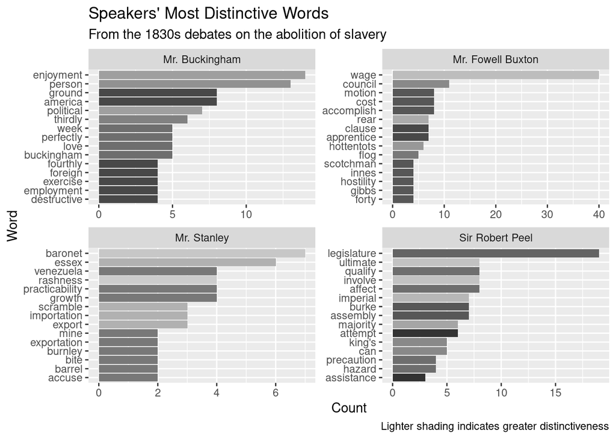

```r
# Visualize the most distinctive words used by each speaker
# - mutate() reorders words within each speaker
# - ggplot() creates a faceted bar chart
# - geom_col() draws bars showing each word's frequency
# - facet_wrap() creates a separate panel for each speaker
# - coord_flip() makes the word labels easier to read
# - scale_fill_grey() represents tf-idf scores in grayscale
most_distinctive_words_per_abolition_speaker %>%
  mutate(word = reorder_within(word, n, speaker)) %>% # Order each speaker's words by frequency
  ggplot(aes(x = word, # Map words to the x-axis
             y = n, # Map word counts to the y-axis
             fill = factor(tf_idf))) + # Shade bars by tf-idf score
  geom_col() + # Draw the bars
  facet_wrap(~speaker, scales = "free") + # Create one panel per speaker
  coord_flip() + # Flip the axes
  scale_x_reordered() + # Preserve word order within panels
  scale_fill_grey() + # Use grayscale shading
  guides(fill = "none") + # Hide the fill legend
  scale_y_continuous(breaks = breaks_pretty()) + # Show whole number counts
  labs(title = "Speakers' Most Distinctive Words", # Add a title
       subtitle = "From the 1830s debates on the abolition of slavery", # Add a subtitle
       caption = "Lighter shading indicates greater distinctiveness", # Add a caption
       x = "Word", # Label the x-axis
       y = "Count") # Label the y-axis
```

Nevertheless, there is room for caveats about settling for these words in particular. From the point of view of text mining, where we look to the number of words as significant, these results are unsatisfying. There are too many small results, where the count is smaller than 5. If we want to write an analysis of each speakers’ referents, this might be a beginning, but we should not rest content that we have the best words for examining the speakers yet. Let’s rerun the code, this time adding instructions to only show us words that appear above a certain threshold by adding just a single line of code. You can play with the number in the filter to see how the results change as we look for more and less distinctive words.

```r
most_distinctive_words_per_abolition_speaker2 <- tfidf_per_top_slavery_speaker_1833 %>%
  group_by(speaker) %>%
  filter(n > 5) %>% # <----------------  this is the only line that's new
  arrange(desc(tf_idf)) %>%
  mutate(rank_tf_idf = row_number()) %>%
  slice(1:15) %>%
  ungroup()

most_distinctive_words_per_abolition_speaker
```

```
## # A tibble: 60 × 5
##    index word       tf_idf     n speaker
##    <int> <chr>       <dbl> <int> <chr>
##  1     1 enjoyment  0.0025    14 Mr. Buckingham
##  2     2 political  0.0025     7 Mr. Buckingham
##  3     3 person     0.0023    13 Mr. Buckingham
##  4     4 thirdly    0.0021     6 Mr. Buckingham
##  5     5 buckingham 0.0018     5 Mr. Buckingham
##  6     6 love       0.0018     5 Mr. Buckingham
##  7     7 perfectly  0.0018     5 Mr. Buckingham
##  8     8 week       0.0018     5 Mr. Buckingham
##  9     9 america    0.0014     8 Mr. Buckingham
## 10    10 ground     0.0014     8 Mr. Buckingham
## # ℹ 50 more rows
```

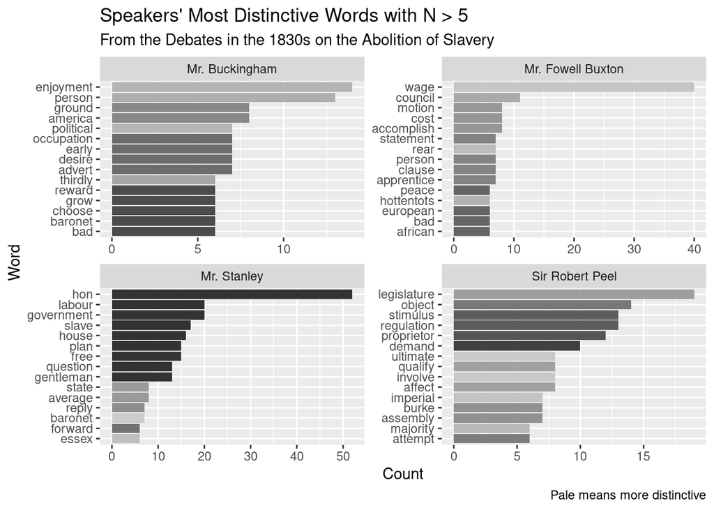

```r
# Visualize the most distinctive words used by each speaker
# - mutate() reorders words by count within each speaker
# - ggplot() creates a faceted bar chart
# - geom_col() draws bars showing each word's frequency
# - facet_wrap() creates a separate panel for each speaker
# - coord_flip() makes the word labels easier to read
# - scale_fill_grey() represents tf-idf scores in grayscale
most_distinctive_words_per_abolition_speaker2 %>%
  mutate(word = reorder_within(word, n, speaker)) %>% # Reorder words by count within each speaker
  ggplot(aes(x = word, # Map words to the x-axis
             y = n, # Map word counts to the y-axis
             fill = factor(tf_idf))) + # Shade bars by tf-idf score
  geom_col() + # Draw the bars
  scale_fill_grey() + # Use grayscale shading
  facet_wrap(~speaker, scales = "free") + # Create one panel per speaker
  coord_flip() + # Flip the axes
  scale_x_reordered() + # Preserve word order within panels
  guides(fill = "none") + # Hide the fill legend
  labs(title = "Speakers' Most Distinctive Words with N > 5", # Add a title
       subtitle = "From the Debates in the 1830s on the Abolition of Slavery", # Add a subtitle
       caption = "Pale means more distinctive", # Add a caption
       x = "Word", # Label the x-axis
       y = "Count") # Label the y-axis
```

At this point, we may want to choose one speaker to inspect in greater detail. Our choice of which speaker to investigate might be motivated by distant reading or not. We are not compelled to investigate Edward Stanley because he spoke more than anyone else. We have used wordcount to guide me to five possible candidates. Nor are we forced to choose which candidate from these five to investigate further on the basis of which words they spoke or which words the computer finds distinctive. We can also make decisions based on outside reading, and good historians usually do.

What might we learn if we looked at Mr. Buckingham’s words in greater detail? The visualizations above limit us to a small number of words per speaker; but we might learn a great deal more by looking at Mr. Buckingham’s favorite words, whether by count of by tf-idf. In fact, the computation for this problem is cheap, so let’s do both.

```r
# Keep the most frequent words used by Mr. Buckingham
# - filter() keeps only rows for Mr. Buckingham
# - arrange() sorts words from most to fewest occurrences
# - slice() keeps the top 40 words
mr_buckingham_slavery_debates <- tfidf_per_top_slavery_speaker_1833 %>% # Start with the tf-idf results
  filter(speaker == "Mr. Buckingham") %>% # Keep only Mr. Buckingham's words
  arrange(desc(n)) %>% # Sort by word count
  slice(1:40) # Keep the top 40 rows

mr_buckingham_slavery_debates
```

```
## # A tibble: 40 × 6
## # Groups:   speaker [1]
##    speaker        word             n      tf   idf tf_idf
##    <chr>          <chr>        <int>   <dbl> <dbl>  <dbl>
##  1 Mr. Buckingham slave           75 0.0193      0      0
##  2 Mr. Buckingham labour          59 0.0152      0      0
##  3 Mr. Buckingham slavery         42 0.0108      0      0
##  4 Mr. Buckingham freedom         38 0.00980     0      0
##  5 Mr. Buckingham free            34 0.00877     0      0
##  6 Mr. Buckingham west            32 0.00825     0      0
##  7 Mr. Buckingham hon             26 0.00670     0      0
##  8 Mr. Buckingham time            26 0.00670     0      0
##  9 Mr. Buckingham emancipation    25 0.00645     0      0
## 10 Mr. Buckingham sugar           25 0.00645     0      0
## # ℹ 30 more rows
```

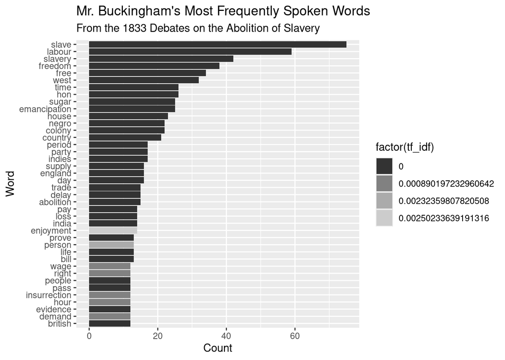

The most frequently used words in Mr. Buckingham’s speeches during the 1833 debates on the abolition of slavery. Bar shading reflects each word’s TF-IDF score, indicating how distinctive the term is relative to other abolitionist speakers. Dark coloring means the term is less distinctive, whereas the light coloring means the term is more distinctive.

```r
# Visualize Mr. Buckingham's most frequently used words
# - mutate() reorders words by count
# - ggplot() creates a bar chart
# - geom_col() draws bars showing each word's frequency
# - coord_flip() makes the word labels easier to read
# - scale_fill_grey() represents tf-idf scores in grayscale
mr_buckingham_slavery_debates %>%
  mutate(word = reorder(word, n)) %>% # Reorder words by count
  ggplot(aes(x = word, # Map words to the x-axis
             y = n, # Map word counts to the y-axis
             fill = factor(tf_idf))) + # Shade bars by tf-idf score
  geom_col() + # Draw the bars
  scale_fill_grey() + # Use grayscale shading
  coord_flip() + # Flip the axes
  labs(title = "Mr. Buckingham's Most Frequently Spoken Words", # Add a title
       subtitle = "From the 1833 Debates on the Abolition of Slavery", # Add a subtitle
       x = "Word", # Label the x-axis
       y = "Count") # Label the y-axis
```

It is interesting that “labour” and “freedom” are used alongside “slavery” and “slave” as Buckingham”s favorite words. Also pronounced are his invocation of “rights,” “wages,” and “people,” suggesting that Buckingham was interested in drawing equivalencies between the rights of working men in Britain and the rights of enslaved people in the West Indies.

If we want to see the words that Buckingham used more than other speakers, we can return to the tf-idf scores that we generated a moment ago. In fact, all we have to do is change a single line of code to produce a visualization showing the top forty most distinctive words and their counts.

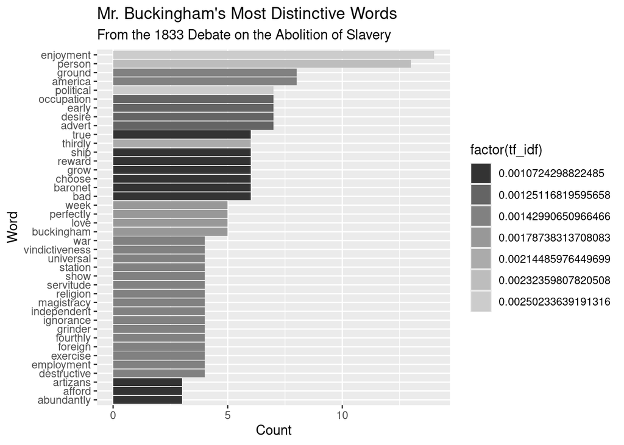

Mr. Buckingham’s most distinctive words in the 1833 debate on the abolition of slavery, showing the terms that appear disproportionately often in his speeches compared to the rest of the abolitionist speakers.

```r
mr_buckingham_slavery_debates2 <- tfidf_per_top_slavery_speaker_1833 %>%
  filter(speaker == "Mr. Buckingham") %>%
  arrange(desc(tf_idf)) %>% # <------- the only line that changed
  slice(1:40)

# Visualize Mr. Buckingham's most distinctive words
# - mutate() reorders words by count
# - ggplot() creates a bar chart
# - geom_col() draws bars showing each word's frequency
# - coord_flip() makes the word labels easier to read
# - scale_fill_grey() represents tf-idf scores in grayscale
mr_buckingham_slavery_debates2 %>% # Start with Mr. Buckingham's words
  mutate(word = reorder(word, n)) %>% # Reorder words by count
  ggplot(aes(x = word, # Map words to the x-axis
             y = n, # Map word counts to the y-axis
             fill = factor(tf_idf))) + # Shade bars by tf-idf score
  geom_col() + # Draw the bars
  scale_fill_grey() + # Use grayscale shading
  coord_flip() + # Flip the axes
  labs(title = "Mr. Buckingham's Most Distinctive Words", # Add a title
       subtitle = "From the 1833 Debate on the Abolition of Slavery", # Add a subtitle
       x = "Word", # Label the x-axis
       y = "Count") # Label the y-axis
```

```r
mr_buckingham_most_distinctive_word <- tfidf_per_top_slavery_speaker_1833 %>%
  filter(speaker == "Mr. Buckingham") %>%
  arrange(desc(tf_idf)) %>%
  slice(1) # <------- the only line that changed; retains the first line only

mr_buckingham_most_distinctive_word
```

```
## # A tibble: 1 × 6
## # Groups:   speaker [1]
##   speaker        word          n      tf   idf  tf_idf
##   <chr>          <chr>     <int>   <dbl> <dbl>   <dbl>
## 1 Mr. Buckingham enjoyment    14 0.00361 0.693 0.00250
```

```r
# finding just the sentences where Buckingham uses the word "wages"
buckingham_sentences <- slavery_debates_1833 %>%
  filter(speaker == "Mr. Buckingham")

buckingham_on_wages <- buckingham_sentences %>%
  filter(str_detect(text, "wages"))

# Display Mr. Buckingham's speeches mentioning wages
# - mutate() wraps long lines for readability
# - select() keeps only the speech text and removes the column name
# - kable() displays the results as a table with a caption
buckingham_on_wages %>%
  mutate(text = str_wrap(text, 80)) %>% # Wrap the text for readability
  select(text) %>% # Keep only the speech text
  kable(col.names = NULL, # Don't display the column name
    caption = "Mr. Buckingham's Mentions of Wages in the 1833 Slavery Debates")
```

Mr. Buckingham’s Mentions of Wages in the 1833 Slavery Debates

[output not shown]

Here they are as plaintext:

```r
# Display Mr. Buckingham's speeches mentioning wages
# - select() keeps only the speech text
# - mutate() wraps long lines for readability
buckingham_on_wages %>%
  select(text) %>% # Keep only the speech text
  mutate(text = str_wrap(text, 80)) # Wrap the text for readability
```

```
## # A tibble: 7 × 1
##   text
##   <chr>
## 1 "As long as slavery was continued, call it by what name they might, whether\n…
## 2 "But all that was intended by the freedom of the negro, in the present instan…
## 3 "But, provided the labourers were free to choose whichever they preferred, it…
## 4 "There were many of these employed at Sheffield (the town he had the honor to…
## 5 "Let the sugar-cultivators of the colonies be as free to choose their occupat…
## 6 "The negroes made each nearly two dollars a-day; and paying one to their mast…
## 7 "A Bill to prolong slavery for twelve years to come, under the specious title…
```

Reading is the essential reason for any choice of formatting. We may expand the number of lines or characters we display by adding an argument to head() (as in head(50) for fifty lines) or changing the second argument of str_wrap(text, 80)) to show a higher number of characters. The analyst’s responsibilty is to use continuously adjust the number of rows of data and characters in order to skim the actual text in question in such a way that promotes their learning – and the learning of any readers whom they intend to educate about their argument.

When we read, we produce understanding. In the lines above, we learn from reading that Buckingham is using the word “wages” in concert with the concepts of “freedom,” “labour,” and “property” to recapitulate a Lockean argument about how property depends on the work of men to enclose land, and how the duty fo the state is to uphold contracts that will protect exchanges built upon this system, upon which capitalism rests. A string of sentences follow about the specificities of wages. But the details are hard to interpret, in part because we are missing important context.

```r
# Show sentence IDs
buckingham_sentences$sentence_id
```

```
##   [1] "S3V0018P0_6605"  "S3V0018P0_6606"  "S3V0018P0_6607"  "S3V0018P0_6608"
##   [5] "S3V0018P0_6609"  "S3V0018P0_6610"  "S3V0018P0_6611"  "S3V0018P0_6612"
##   [9] "S3V0018P0_6613"  "S3V0018P0_6614"  "S3V0018P0_6615"  "S3V0018P0_6616"
##  [13] "S3V0018P0_6617"  "S3V0018P0_6618"  "S3V0018P0_6619"  "S3V0018P0_6620"
##  [17] "S3V0018P0_6621"  "S3V0018P0_6622"  "S3V0018P0_6623"  "S3V0018P0_6624"
##  [21] "S3V0018P0_6625"  "S3V0018P0_6626"  "S3V0018P0_6627"  "S3V0018P0_6628"
##  [25] "S3V0018P0_6629"  "S3V0018P0_6630"  "S3V0018P0_6631"  "S3V0018P0_6632"
##  [29] "S3V0018P0_6633"  "S3V0018P0_6634"  "S3V0018P0_6635"  "S3V0018P0_6636"
##  [33] "S3V0018P0_6637"  "S3V0018P0_6638"  "S3V0018P0_6639"  "S3V0018P0_6640"
##  [37] "S3V0018P0_6641"  "S3V0018P0_6642"  "S3V0018P0_6643"  "S3V0018P0_6644"
##  [41] "S3V0018P0_6645"  "S3V0018P0_6646"  "S3V0018P0_6647"  "S3V0018P0_6648"
##  [45] "S3V0018P0_6649"  "S3V0018P0_6650"  "S3V0018P0_6651"  "S3V0018P0_6652"
##  [49] "S3V0018P0_6653"  "S3V0018P0_6654"  "S3V0018P0_6655"  "S3V0018P0_6656"
##  [53] "S3V0018P0_6657"  "S3V0018P0_6658"  "S3V0018P0_6659"  "S3V0018P0_6660"
##  [57] "S3V0018P0_6661"  "S3V0018P0_6662"  "S3V0018P0_6663"  "S3V0018P0_6664"
```

[output cut: 51 more lines]

Missing information is the result of our strategy of identifying words like “slavery” and “wages” that appear within the same sentence. For the purpose of picking up on general patterns, this manner of counting and generalizing is useful. But if we abstract sentences from their context, it is almost impossible to tell what is going on.

Fortunately, we are not constrained by filtering for words. We can always go back to the original context of the speech or debate in which a sentence appears. We can use our list of `sentence_id` numbers to call up the entire speeches of which each sentence is a part (further down we will explain more about the technicalities of what happens in this section).

If we were working on a paper analyzing these speeches, we would likely want to read Buckingham’s speeches about slavery in their entirety; the same would be true if our research project concerned the corporate reports of a company or a series of lawsuits. The process of reading and understanding cannot be replaced by counting words and analyzing them. Students of data science who pursue wordcount without background reading inevitably arrive at weak, useless or nonsensical results.

For the moment, let us proceed by reading a limited sample of Buckingham’s speeches about slavery – just those speeches in which he invoked the word “wages.”

The code for obtaining the speeches is given below.

```r
# Keep the sentence IDs from Mr. Buckingham's speeches
# - select() keeps only the sentence_id column
buck_sentence_ids <- buckingham_sentences %>%
  select(sentence_id) # Keep only the sentence IDs

# Find the speech IDs for Mr. Buckingham's speeches
# - left_join() adds the speech IDs from the file metadata
# - select() keeps only the speech_id column
buck_speech_ids <- buck_sentence_ids %>%
  left_join(file_metadata_1830) %>% # Add the speech IDs
  select(speech_id) # Keep only the speech IDs

# Find all sentences in Mr. Buckingham's speeches
# - left_join() adds the sentence IDs for each speech
# - select() keeps only the sentence_id column
# - left_join() retrieves the corresponding Hansard sentences
buck_speeches <- buck_speech_ids %>%
  left_join(file_metadata_1830) %>% # Add the sentence IDs
  select(sentence_id) %>% # Keep only the sentence IDs
  left_join(hansard_1830, relationship = "many-to-many") # Retrieve the corresponding sentences
buck_speeches %>%
  head() %>%
  kable()
```

| sentence_id | text |
| --- | --- |
| S3V0018P0_6605 | rose amidst confusion, and said, that if he had been in the habit of frequently addressing the House, or when addressing it, of trespassing on its time at any great length, there might be some reason … |
| S3V0018P0_6606 | Gentlemen’s speeches, and bring them all within a moderate compass: and though his proposition had not been adopted, and a great waste of the public time had consequently been allowed to take place, y… |
| S3V0018P0_6607 | In the lateness of the hour, he should feel an additional reason for condensation and brevity; but, as he intended to touch on a branch of the question hitherto undebated, and to show the preference o… |
| S3V0018P0_6608 | When the Government plan was so ably and fully developed by the right hon. |
| S3V0018P0_6609 | the Secretary for the Colonies, he felt that there were many parts of it extremely objectionable; and, if he had had an opportunity, at an earlier period of the debate, to have explained the grounds o… |
| S3V0018P0_6610 | But, for the present, he would content himself with saying, that the two principal features to which he should object were these—namely, the protraction of the period of emancipation to twelve years, … |

With missing sentences added back in, the speeches in their entirety are much easier to understand.

Mr. Buckingham began his long speech by introducing the three constituencies who demanded the abolition of slavery. Some are motivated by religion, others by claims about freedom, justice, and the British Constitution; and still others on moral or economic grounds, which Buckingham summarized as “policy alone.”

Reviewing the call from religious circles for immediate abolition, and from policy and constitutional circles for delay, we see Buckingham invoking “wages” in the midst of a detailed case for immediate abolition. He challenges the proposals in the 1834 legislation to abolish slavery that called for a period of “apprenticeship,” when enslaved people would be nominally freed but still forced to work without pay. The bill that finally passed would require apprenticeship, and historians have since argued that this unwillingness to end slavery represents a failure of the British state to commit to freedom. In Buckingham’s arguments, we see the politician as a man ahead of his time – arguing that “apprenticeship” or “servitude” was an undisguised synonym for slavery, and denouncing any act that extended the period of enslavement.

We also see, in the second speech, we see Buckingham extraoplating from his experience of working with forced labor on naval vessels to the question of apprenticeship. We see him calling up another one of his more distinctive keywords – “America” – to make the case that the independent United States provided a historical example of the success of freeing an expensive colony to self-government.

Buckingham’s commitments to endorse the humanity and rights of enslaved humans are abundantly clear. We see him making a detailed argument against the category of race itself as the basis for political or economic assumptions, especially assumptions about inferiority. He makes a case for dark-skinned people freely associating and participating in the economies of the Mediterranean, invoking ancient Egypt and the biblical Queen of Sheba too argue that dark-skinned Africans and their interracial descendents were destined for economic success.

We see Buckingham arguing that the free market naturally rewards laborers who choose dangerous work. Buckingham later generalizes about the rewards of a free market from his experience in Sheffield observing steel grinders and the high wages they commanded. Buckingham is arguing that only the freedom of wages – not apprenticeship – will induce formerly enslaved men to take on challenging work.

But we are not done. We can use the distinctive words in our list to investigate other aspects of the speech.

```r
# Find Mr. Buckingham's speeches mentioning "enjoyment"
# - left_join() adds speaker information
# - filter() keeps only Mr. Buckingham's speeches that mention "enjoyment"
buckingham_sentences_enjoyment <- slavery_debates_1830 %>%
  left_join(speaker_metadata_1830) %>% # Add speaker metadata
  filter(speaker == "Mr. Buckingham", # Keep only Mr. Buckingham's speeches
         str_detect(text, "enjoyment")) # Keep speeches mentioning "enjoyment"

# Display Mr. Buckingham's speeches mentioning enjoyment
# - mutate() creates a descriptive column name
# - select() keeps only the speech text
# - kable() displays the results as a table without a column name
buckingham_sentences_enjoyment %>%
  select(text) %>% # Keep only the speech text
  kable(col.names = NULL,
        caption = "Mr. Buckingham's Mentions of Enjoyment in the 1833 Slavery Debates")
```

Mr. Buckingham’s Mentions of Enjoyment in the 1833 Slavery Debates

| But when freedom had been granted—when the yoke had been taken off—when every man might seek his own employer, and fix his own terms of reward; when the blacks were elevated to the same enjoyment of e… |
| --- |
| All men disliked to labour more than was necessary to obtain for them the enjoyments of life; beyond this, they desired leisure, or at least the entire direction and control over the employment of the… |
| And, as all slaves hitherto made free had bettered their condition from the moment of their freedom being attained, there was no good reason for doubting but that all the slaves in future to be emanci… |
| The negroes being released from their present degraded and depressed condition, would become subject to new motives, animated by new hopes, and cheered by new enjoyments. |
| The developement of every new mental faculty would expand the desire for further intellectual attainment; and thus the now dormant powers of the negro mind would be brought out into progressively incr… |
| He would begin, then, with the objections to immediate emancipation, which were raised by the noble Lord, the member for Stirling (Lord Dalmeny), which embraced the three following assertions:—That th… |
| If it were intended to confer at once upon the negro the enjoyment of political rights, the trust of the elective franchise, or elevation to judicial or other stations of civil or political authority,… |
| no more was asked)—it must be equally safe to admit the full enjoyment of the right contended for to every slave, whatever the degree of ignorance in which it might be his misfortune to be found. |
| We never could prepare them for freedom, but by making them partake of its enjoyment. |
| If free labour were more productive than slave labour (as by the evidence read he had abundantly shown), it must then follow, that both masters and slaves would be enriched thereby—and the desire for … |
| The source of discontent was, that the negroes were compelled to labour excessively, by coercion and terror of the whip, and were badly fed and badly clothed, though they laboured in crop-time eightee… |
| It was this:—“That as the only delay required for the safe and satisfactory commencement of this great act of national justice, will be such a period of time as may admit the due preparation of measur… |
| Fourthly, —As to the benefit of the West-India proprietors;—nothing could so effectually do this as a Bill which should guarantee to them, on the faith of the nation, the full enjoyment of the actual … |
| He regretted that he had heard of no provision being made, during this state of probation or apprenticeship, for the education or religious instruction of any class of the slaves; and yet it must be e… |

If the example of “wages” furnished sentences difficult to understand without broader context, the sentences about “enjoyment” give an example where Buckingham’s case is clear without any further effort peering into the text. His utopian vision of capitalism becomes clear in these passages, which posit the conjecture that the freedom to work on a wage market gives labourers access to “enjoyment,” and that enjoyment and its natural incentives therefore offers a reason why the slaves should be freed.

```r
# Find Mr. Buckingham's speeches mentioning love
buckingham_sentences_love <- slavery_debates_1830 %>%
  left_join(speaker_metadata_1830) %>% # Add speaker metadata
  filter(speaker == "Mr. Buckingham", # Keep only Mr. Buckingham's speeches
         str_detect(text, "love")) # Keep speeches mentioning "love"

# Display Mr. Buckingham's speeches mentioning love
# - mutate() wraps long lines for readability
# - mutate() creates a descriptive column name
# - select() keeps only the speech text
# - kable() displays the results as a table without a column name
buckingham_sentences_love %>% # Start with speeches mentioning love
  mutate(text = str_wrap(text, 80)) %>% # Wrap the text for readability
  select(text) %>% # Keep only the speech text
  kable(col.names = NULL,
        caption = "Mr. Buckingham's Mentions of Love in the 1833 Slavery Debates")
```

Mr. Buckingham’s Mentions of Love in the 1833 Slavery Debates

| It could not be denied, that the love of ease was as common to the negro race as |
| --- |
| to every other. |
| If it were intended to confer at once upon the negro the enjoyment of political |

We might also elect to investigate “love,” one of the words that appeared highly ranked through tf-idf but relatively sparse. We investigated the word because we felt that it might represent one of a set of virtues to which Buckingham looked – alongside “universal,” “desire,” and “religion.”

This is a dead end. When we consult the text, we do not find an endorsement of “love” as a universal virtue that we hypothesized when we looked at the word list. Instead, we find the use of phrases such as “love of ease,” “love of liberty,” and “love of repose,” as Buckingham invokes conjectures about the motivations of humankind, endorsing none of them. It would be foolhardy to make any kind of a positive argument about statements so diverse as these. We could try to unify them under one statement, but we would be falsifying evidence. In a research paper we will have no use for these examples, and we will pass over the word “love” without remark.

```r
# Find Mr. Buckingham's speeches mentioning "universal"
buckingham_sentences_universal <- slavery_debates_1830 %>%
  left_join(speaker_metadata_1830) %>%
  filter(speaker == "Mr. Buckingham",
         str_detect(text, "universal"))

# Make a table
buckingham_sentences_universal %>%
  head() %>% # just the first few rows
  mutate(text = str_wrap(text, 80)) %>% # just the first few lines
  select(text) %>% # only the one column
  kable(col.names = NULL,
        caption = "Mr. Buckingham's Mentions of Universal in the 1833 Slavery Debates")
```

Mr. Buckingham’s Mentions of Universal in the 1833 Slavery Debates

| The motives which had led to the almost universal demand throughout this country |
| --- |
| for the abolition of slavery were three-fold. |
| The rule was universal, that men never rebelled because freedom was granted to |

We find in these sentences Buckingham invoking “universal” in the sense of an Enlightenment mandate, whether an expression of consensus or natural laws. Democratic demand for the abolition of slavery is an expression of a “universal” sentiment (sentences 1, 3 and 4). “Universal” laws govern behavior, including the fact that rebellion is more scarce in free nations (sentence 2). Universal truths, revealed through democratic processes, give the basis for legislation, according to Buckingham.

Presented with these particular sentences, having read some of Buckingham’s arguments at greater length, we may feel confident that we understand how he has used the words. As we are making a wider argument about the use of words, buttressed by several examples, we do not necessarily need to follow every single sentence back to its original context.

```r
# Find Mr. Buckingham's speeches mentioning "desire"
buckingham_sentences_desire <- slavery_debates_1830 %>%
  left_join(speaker_metadata_1830) %>%
  filter(speaker == "Mr. Buckingham",
         str_detect(text, "desire"))

buckingham_sentences_desire %>%
  head() %>% # just the first few rows
  mutate(text = str_wrap(text, 80)) %>% # just the first few lines
  select(text) %>% # only the one column
  kable(col.names = NULL,
        caption = "Mr. Buckingham's Mentions of Desire in the 1833 Slavery Debates")
```

Mr. Buckingham’s Mentions of Desire in the 1833 Slavery Debates

| All men disliked to labour more than was necessary to obtain for them the |
| --- |

The sole sentence we can’t understand without broader context is Sentence #5. Let’s inspect the sentence to obtain the sentence ID number.

```r
buckingham_sentences_desire[5]
```

```
## # A tibble: 7 × 1
##    year
##   <dbl>
## 1  1833
## 2  1833
## 3  1833
## 4  1833
## 5  1833
## 6  1833
## 7  1833
```

```r
# Retrieve the sentences surrounding the missing context
# - filter() keeps only the selected sentence IDs
missing_context <- hansard_1830 %>%
  filter(sentence_id %in% c("S3V0018P0_8990",  # Keep the selected sentences
                            "S3V0018P0_8991",
                            "S3V0018P0_8992",
                            "S3V0018P0_8993"))
missing_context %>%
  head() %>%
  mutate(text = str_wrap(text, 80)) %>%
  select(text) %>%
  kable()
```

| text |
| --- |
| The source of discontent was, that the negroes were compelled to labour |

In Sentence #5, Buckingham is talking about how workers will pursue dangerous and difficult jobs when motivated by desire (“gain, honour, promotion, and prize-money.”) For this reason, Buckingham concluded that “promotion was the desire of all,” and that, if allowed to pursue them, the prospect of wages would incentivize formerly enslaved people as it had incentivized British navies to work hard in the pursuit of earnings.

### Pulling Together an Analysis

In the foregoing exercises, we have investigated many dimensions of text use in the debates over slavery. We have come up with hypotheses and tested some (if not all) of them. We have read words in context, returning to the text for more sentences when we needed more information. The material that we now have is enough to make an argument about Buckingham’s use of words to make an argument about capitalism that supported the immediate abolition of slavery.

We have applied our personal judgment in deciding when word lists are enough by themselves, when a few sentences can inform our understanding, and when we need to return to the speeches themselves for more context. Cultivating the judgment to know when to trust data, when to look for more context, and when to leave out an example entirely is one of the most important skills of the digital historian – and it is a skill almost never tught in departments of Comptuer Science or Data Science. Understanding which course to pursue is a matter of training, instinct, broad reading, and a willingness to engage all the tools. The interpreter who uses word count skilfully has no automatic answer for how to interpret a given speaker or given text; the top words are no sure guide, nor is tf-idf, nor the sentences linked to them. Only by knowing when to move from short sentences to longer speeches, reading the speeches in context, and examining the words thoughtfully is an adequate opinion of the text formed.

How much of the work should I show in this case? The answer may be surprising. None of them.

The process of testing hypothesess laid out here is considered part of the research. Most of the visualizations and discussion would not form part of a term paper, let alone a published paper. They are like the wood shavings that fill a workshop; they are evidence of the labor that has gone into making an ultimate artifact at which we aim, which is surprising knowledge about the past. At the end of the day, the shavings are swept from the workshop floor to be discarded or composted. They are not to be treasured or preserved. Just so with much of the intermediate work of reading, counting, and modeling that goes into the making of an insightful historical analysis. There is no shortcut through it. No language model gives us a substitute for thinking about words and their meaning.

The graphs we made heretofore give us context that would otherwise be invisible. If not for text mining, we would have little idea that Buckingham and Buxton both spoke about wages disproportionately to Stanley and Peel. We might select other terms through close reading that catch our eye, and we might write about how the speakers used these words to support an argument. In any case, that is the task ahead of us — to show how speakers used their words to make a political case. But without text mining, the basis for the selection of words would be hopelessly colored by our individual prejudices. We can make a fundamentally more objective case for which words we focus on when we approach the problem through text mining.

To make an argument about Buckingham’s use of words, what we need is (1) a list of the words we chose to investigate and a statement of the role that text mining played in selecting them, and (2) a close reading of the words in context that proves that we read Buckingham’s speeches.

For the purpose, we do not need to show the reader the output of our tf-idf or word count process. Instead, a list of words will suffice. In the prose, we would spend a sentence or two describing the process we went through of applying tf-idf with and without a threshold to inspect Buckingham’s distinctive words when compared with four other top speakers in the debates. If we want the list formatted nicely, we might write some code like this:

```r
# Create a list of words to analyze
my_words <- c("wage", "enjoyment", "love", "universal", "desire")

# Find the tf-idf scores for the selected words
# - filter() keeps only Mr. Buckingham's selected words
# - ungroup() removes the previous grouping
# - select() keeps only the relevant columns
# - mutate() rounds the tf-idf scores
# - arrange() sorts the words from highest to lowest tf-idf score
my_words_w_tfidf <- tfidf_per_top_slavery_speaker_1833 %>% # Start with the tf-idf results
  filter(speaker == "Mr. Buckingham", # Keep only Mr. Buckingham's words
         word %in% my_words) %>% # Keep only the selected words
  ungroup() %>% # Remove the grouping
  select(word, n, tf_idf) %>% # Keep the relevant columns
  mutate(tf_idf = round(tf_idf, 4)) %>% # Round the tf-idf scores
  arrange(desc(tf_idf)) # Sort by tf-idf score

kable(my_words_w_tfidf,
      caption = "Some of Mr. Buckingham's Most Distinctive Words in Debates About Slavery")
```

Some of Mr. Buckingham’s Most Distinctive Words in Debates About Slavery

| word | n | tf_idf |
| --- | --- | --- |
| enjoyment | 14 | 0.0025 |
| love | 5 | 0.0018 |
| universal | 4 | 0.0014 |
| desire | 7 | 0.0013 |
| wage | 12 | 0.0009 |

As to the substance of the argument, we have most of the interpretive work above in the sentences that move, word by word, through a synopsis of the arguments Buckingham made about slavery, through his use of the words “desire” and “universal” to sketch out the enlightenment system of perfection that he believed made immediate abolition both inevitable and desirable, and finally through his identification of “wages” as the crucial mechanism that made it possible for men’s willingness to endure dangerous work to be rewarded and thus workers to be incentivized to learn and apply themselves – something slavery could not provide. We might cut and paste into a new series of paragraphs our piecemeal analyses above of words in context. We might reshape the resulting paragraph with topic and concluding sentences into a series of arguments supported by evidence. The resulting argument, based on the actual words of the primary text, will be – above all – highly persuasive, because it is composed solely of arguments and pieces of evidence, each argument corresponding to a series of pieces of evidence.

At the risk of repetition, let us review this key point: text mining is not meant to save us from reading. It is meant to help us read better. The positive result of text mining is a precise understanding of the words used to make particular arguments by historical actors, alongside a statistical understanding of which words mark out individuals from their peers. The best outcome of engaging in a text mining project should be judged not by the fanciness of the graph that we produce but by the seriousness with which the analyst engages original texts and their language.

To pursue a question seriously means being willing to walk into blind alleys in search of some historical surprise. The frustrating fact of our work so far is that it has not produced anything astonishing. That advocates of the abolition of slavery invoked what they believed to be the utopian aspects of capitalism as an argument has been noted by previous generations of historians. That Buckingham had a specific vocabulary with which to engage capitalism – enjoyment, wages, the universal, and desire being its keywords – may be a new finding, but it’s hardly headline news.

The work we have performed thus far gives us the material for a 3-page paper that demonstrates competence but not insight.

To move forward towards insight, we would want to return to our hypotheses and perform more comparisons. Whether the goal is a five- or ten-page paper or a corporate report, we will need to demonstrate that our method can discover something fundamentally new.